# Shock Modification by Cosmic-Ray-Excited Turbulences

Reference: Terasawa2007Progress of Theoretical Physics Supplement

## Governing Equation

The parameters, $\alpha$ and $\xi$, added to the governing equations indicate how strong pressures excited by Alfven and sound waves are.

\begin{gathered} {\rho _1}{U_1} = {\rho _2}{U_2} \equiv j \hfill \\ j{U_1} + {P_1} = j{U_2} + {P_2} + \alpha {P_2} + \xi {P_2} \hfill \\ \frac{j}{2}U_1^2 + \frac{\gamma }{{\gamma - 1}}{P_1}{U_1} = \frac{j}{2}U_2^2 + \frac{\gamma }{{\gamma - 1}}{P_2}{U_2} + 3\alpha {P_2}{U_2} + \frac{3}{2}\xi {P_2}{U_2} \hfill \\ {P_1} = {P_{g1}} + {P_{CR1}} \hfill \\ {P_2} = {P_{g2}} + {P_{CR2}} \hfill \\ \end{gathered}

## Deriving the Compression Ratio

Here we define \begin{gathered} a \equiv 1 + \alpha + \xi \hfill \\ b \equiv \frac{\gamma }{{\gamma - 1}} + 3\alpha + \frac{3}{2}\xi. \hfill \\ \end{gathered}

They are rewritten as \begin{gathered} {\rho _1}{U_1} = {\rho _2}{U_2} \equiv j \hfill \\ j{U_1} + {P_1} = j{U_2} + a{P_2} \hfill \\ \frac{j}{2}U_1^2 + \frac{\gamma }{{\gamma - 1}}{P_1}{U_1} = \frac{j}{2}U_2^2 + b{P_2}{U_2}. \hfill \\ \end{gathered}

Eliminating $P_2$, we get $$\left( {1 + 2\frac{\gamma }{{\gamma - 1}}\frac{1}{{{M^2}}}} \right){r^2} - \frac{{2b}}{a}\left( {1 + \frac{1}{{{M^2}}}} \right)r + \left( {\frac{{2b}}{a} - 1} \right) = 0.$$ Here $M=\sqrt{\rho U_1^2/P_1}$.

In a strong shock limit ($M\rightarrow \infty$), the compression ratio reduces to $$r = \frac{{\left( {\gamma + 1} \right) + \left( {\gamma - 1} \right)\left( {5\alpha + 2\xi } \right)}}{{\left( {\gamma - 1} \right)\left( {1 + \alpha + \xi } \right)}}.$$

```python
%config InlineBackend.figure_format = 'retina'
import numpy as np
import matplotlib.pyplot as plt
plt.rcParams['font.size'] = 14
plt.rcParams['axes.linewidth'] = 1.5
```

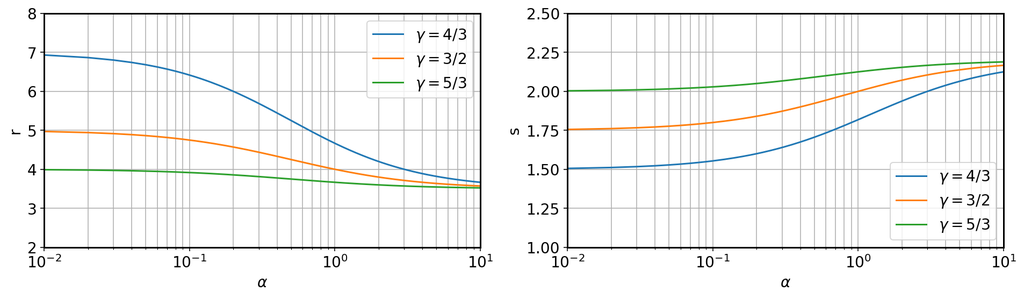

```python
def CRMS(gam):
    alph =np.linspace(0.01,10,1000)
    xi=alph
    r=((gam+1)+(gam-1)*(5*alph+2*xi))/(gam-1)/(1+alph+xi)
    s=(r+2)/(r-1)
    return r,s

plt.figure(figsize=(16,4))
plt.subplot(121)
plt.plot(alph,CRMS(4/3)[0], label=r'$\gamma=4/3$')
plt.plot(alph,CRMS(3/2)[0], label=r'$\gamma=3/2$')
plt.plot(alph,CRMS(5/3)[0], label=r'$\gamma=5/3$')
plt.legend()
plt.xlabel(r'$\alpha$'); plt.ylabel('r')
plt.xlim(0.01,10); plt.ylim(2,8)
plt.xscale('log')
plt.grid(True,which="both",ls="-")

plt.subplot(122)
plt.plot(alph,CRMS(4/3)[1], label=r'$\gamma=4/3$')
plt.plot(alph,CRMS(3/2)[1], label=r'$\gamma=3/2$')
plt.plot(alph,CRMS(5/3)[1], label=r'$\gamma=5/3$')
plt.legend()
plt.xlabel(r'$\alpha$'); plt.ylabel('s')
plt.xlim(0.01,10); plt.ylim(1,2.5)
plt.xscale('log')
plt.grid(True,which="both",ls="-")

plt.show()
```